# Algunos consejos para los trabajos

Programación y manejo de datos con R  
(Web del curso [aquí](https://perezp44.github.io/intro-ds-26-27-web/))

# En pocas palabras

Un trabajo final tiene **una pregunta** (o preguntas), **unos datos y algunas respuestas** (o resultados)

Primero veremos algunos consejos sobre cómo **empezar el trabajo**; después, la **estructura del trabajo**

**Importante!!!** los trabajos no tienen que estar perfectos, **decentes** sí. Y lo que voy a contar aquí son consejos, no normas

## Antes de ponerte con el código …

- Piensa **qué quieres averiguar** y qué sabes ya del tema (igual conviene leer algo antes de concretar)
- Ponle un **título provisional**: ayuda bastante a ver qué quieres hacer
- Cuenta tu idea al profesor antes de avanzar mucho
- Después, monta la **estructura** del trabajo: crea los apartados vacíos y ve rellenándolos poco a poco
- Título y resumen
- Introducción
- Datos
- Análisis
- Resultados
- Conclusiones
- Bibliografía

## En la medida de lo posible, elige una pregunta, no un tema

- Un tema: “El mercado de la vivienda”
- Una pregunta: “¿Dónde ha subido más el alquiler desde 2015?”

Una buena pregunta te interesa, cabe en una frase y se puede tratar de responder con datos

**¿Cómo acotar la pregunta?**

- Lo primero, **mira qué datos hay**: una pregunta que no se puede contestar con datos no nos sirve
- Mejor una pregunta pequeña bien contestada que una grande a medias
- … y tranquilo, la pregunta puede cambiar mientras trabajas

Si dudas entre dos ideas, igual, solo igual, conviene elegir la que tenga datos más fáciles de conseguir

## Introducción: de qué trata el trabajo y por qué interesa

- La **pregunta** y por qué interesa
- Qué se sabe ya del tema (varios párrafos, con sus citas)
- De dónde salen los datos y qué vas a hacer con ellos

Con una página suele bastar. Y un truco: es más fácil escribirla al final, cuando ya sabes qué has encontrado

## Datos: ¿dónde encontrarlos?

- *There are a lot of data out there* … por ejemplo, [aquí](https://perezp44.github.io/Rflowers.2024/blog_TBits/003_datos_para_estudiantes.html) tienes un listado amplio
- Creo que mejor de organismos oficiales: [INE](https://www.ine.es), [Eurostat](https://ec.europa.eu/eurostat), [Banco Mundial](https://data.worldbank.org) …
  - Recuerda que muchos organismos oficiales tienen paquetes de R que facilitan la descarga de datos. Por ejemplo [aquí](https://perezp44.github.io/intro-ds-26-27-web/materiales/slides_04_cargar-datos.html#/section-15)
- Si usas varias fuentes de datos y las unes, mejor que mejor

Búscalos pronto y, antes de decidirte, comprueba que **puedes descargar los datos y cargarlos en R**

## ¿Son fiables los datos? Míralos bien antes de decidirte

**En el trabajo tendrás que contar todo sobre los datos**: la fuente, qué es cada fila, qué variables usas y qué has limpiado o quitado, y por qué, …

**De dónde vienen**

- Fíjate en **quién publica** los datos (mejor un organismo oficial o un autor conocido), si explica cómo se han obtenido y si están actualizados
- Si los has visto en un periódico o en un blog, busca la fuente original
- Lo mismo con lo que leas sobre el tema. Para leer, mejor [Google Académico](https://scholar.google.es), la biblioteca, informes de organismos (INE, Banco de España, OCDE …) …

**Qué hay dentro**

- ¿Qué es cada fila? un país, un año, una persona …
- ¿Cuántos `NA` hay en las variables que vas a usar?
- ¿En qué unidades están? euros o miles, porcentajes o tantos por uno …
- Y guarda una copia en la carpeta del trabajo: los datos de una web pueden cambiar

**Consejo**: apunta de dónde sale cada dato y cada idea al encontrarlo, con su enlace, en un archivo aparte. Luego no te acordarás!!

## Análisis: principales pasos

Tendrás que aplicar lo que vamos viendo (de R) en el curso o lo que ya sepas o vayas aprendiendo por ti mismo

- Cargar los datos
- **Arreglarlos**: `filter()`, `mutate()`, `pivot_longer()`, `left_join()` …
- **Resumirlos**: `group_by()` y `summarise()`, …
- **Mostrarlos**: gráficos, tablas, mapas, …

**Algunos consejos**:

- Avanza paso a paso y mira cada resultado
- Después de un `left_join()`, cuenta las filas
- Siempre que puedas, compara algún resultado con una cifra que ya conozcas
- Para comparar países o provincias, mejor porcentajes o valores por habitante
- Si un paso **no ayuda a responder la pregunta**, igual sobra

## Escribe código que se pueda leer

- **Nombres cortos e intuitivos**: `df_alquiler` (good) `df2_bueno_final` (not good)
- Un comentario corto en cada bloque explicando por qué haces lo que haces
- Rutas relativas, no `C:/Users/...`
- **Borra lo que no uses**

Si no sabes explicar una línea de tu código, párate a entenderla. **También si viene de la IA!!!**

**Y para trabajar más cómodo**:

- Quizás sea mejor empezar a trabajar el código en scripts y, al principio, poner en el `.qmd` solo el texto; los chunks, para el final
- Si trabajas ya con el `.qmd` renderiza a menudo (si alguna sección tarda mucho en ejecutarse pon `#| eval: false` en su chunk)

## Resultados: un gráfico, una idea

- Mejor pocos gráficos y cuidados que muchos hechos deprisa: elige los que ayudan a responder la pregunta
- Cada gráfico debería contar **una cosa**; si cuenta tres, igual son tres gráficos
- Un título que diga lo que se ve, ejes con nombre y unidades, y la fuente en el `caption`
- Categorías ordenadas por su valor (`fct_reorder()`); si hay muchas, puedes destacar unas pocas o usar `facet_wrap()`
- Debajo de cada gráfico, **dos o tres frases**: qué se ve, qué tiene que ver con tu pregunta y si algo te ha sorprendido

## Por ejemplo …

Así, no

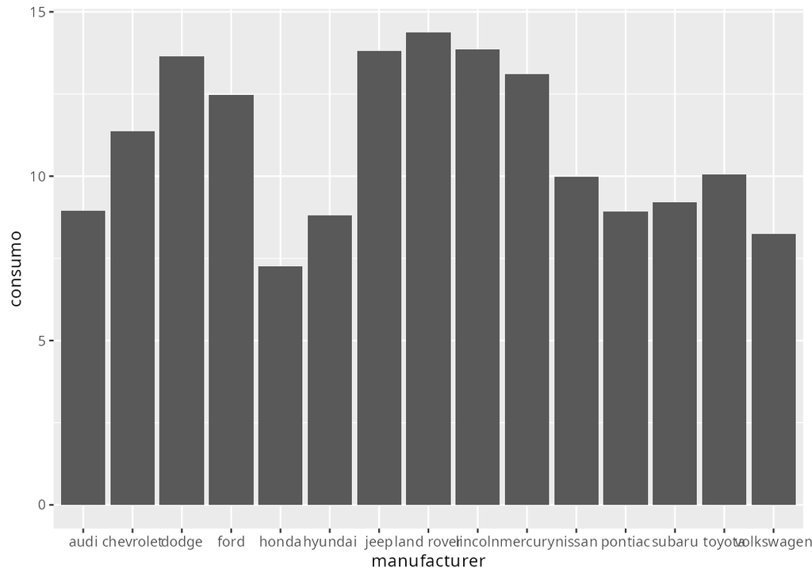

Sin título, sin unidades y sin fuente. Las marcas, en orden alfabético y que casi no se leen

Mejor así

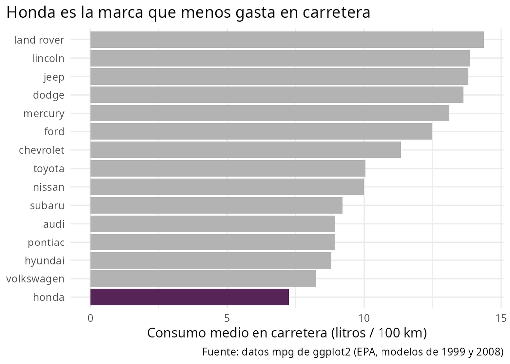

El título dice la idea, las barras van ordenadas y Honda destaca. Y con unidades y fuente

## ¿Y las tablas y los mapas?

- Una tabla, si importan las cifras exactas (pocas filas y pocos decimales)
- Un mapa, si el lugar importa; si no, igual basta con un gráfico de barras
- No hace falta usar todo lo visto en clase
- Las tablas y los mapas, al igual que los gráficos, hay que comentarlos

Siempre puedes poner una sección al final de extras o “tomas falsas” con gráficos que no aportan mucho, pero que te han parecido curiosos, o simplemente bonitos

## Conclusiones: vuelve a la pregunta e intenta responderla

- La respuesta, en 3 o 4 frases
- Lo que no has podido averiguar …
- … y qué harías con más tiempo o más datos
- Cuidado con decir “causa” o “demuestra”: casi siempre solo vemos **relaciones**

“Con estos datos no se puede saber …” también es una conclusión

Y el resumen, lo último: 4 o 5 frases con la pregunta, los datos y la respuesta

## Bibliografía: cita todo lo que has usado

- **Todo** lo que has usado: los datos (fuente y enlace), lo que has leído, los paquetes que no hemos visto en clase y las ideas y el código de otros (blogs, artículos, otros trabajos)
- La IA también, si la has usado: di para qué
- Cita en el texto, donde usas el dato o la idea, y pon la lista completa al final (con el mismo formato en todas)
- Puedes inspirarte en otros trabajos (los de otros años están [aquí](https://perezp44.github.io/intro-ds-26-27-web/05-trabajos-estudiantes.html)), PERO di de dónde sale cada cosa: copiar sin citar es plagio, aunque cambies algunas palabras

En Quarto, las referencias van en un fichero `.bib` (`bibliography: referencias.bib` en el YAML) y se citan con `@clave`. Para saber cómo citar un paquete de R: `citation("paquete")`

## Antes de entregar: repásalo con calma, no el último día

- ¿Se renderiza entero, sin errores?
- ¿Funciona en otro ordenador? (rutas relativas y datos incluidos)
- ¿Cargas todos los paquetes al principio? ¿Has quitado los `install.packages()`?
- ¿Cada gráfico tiene título, fuente y comentario?
- ¿Están citados los datos y lo que has leído?
- ¿Quedan *warnings* o mensajes en el documento?
- ¿Has pasado el corrector ortográfico?
- ¿Lo ha leído otra persona y lo ha entendido?

# Good Luck con los trabajos!!!! 🍀 💪

Y si te atascas, pregunta pronto: en clase o en tutorías

Si quieres inspirarte, [aquí](https://perezp44.github.io/intro-ds-26-27-web/05-trabajos-estudiantes.html) tienes los trabajos de otros años

Parte de estos consejos sale del vídeo [Cómo plantear trabajos académicos](https://www.youtube.com/watch?v=Q0lOs8IY7Bk), de las Bibliotecas de la UNED